# FEMA Hazard Mitigation projects analysis

Andrew Ba Tran

The analysis done by The Post for the story [The Ring in Ashes](https://www.washingtonpost.com/nation/2021/11/15/fema-hazard-mitigation-funding/) can be reproduced using FEMA’s Hazard Mitigation Assistance Projects open data and joined with with FEMA’s Disaster Declarations Summaries data to determine which designated disasters occurred between three time periods

```r
library(tidyverse)
library(tidycensus)
library(lubridate)
library(DT)
library(knitr)
library(viridis)
library(scales)

knitr::opts_chunk$set(warning = FALSE)
knitr::opts_chunk$set(message = FALSE)
knitr::opts_chunk$set(fig.width = 8)
knitr::opts_chunk$set(fig.height = 3)

# load up cleaned up data
mega_df <- readRDS("../../data/clean/mega_df_pt2.RDS") %>%
  mutate(declaration_year=year(declarationDate)) %>%
  filter(programArea=="HMGP")
```

Of the $11 billion FEMA has allocated for this program over the past decade, only $1.6 billion has been spent.

```r
# 1. What percent of money is unspent
share1 <- mega_df %>%
   #filter(programFy>2010) %>%
   mutate(year_declared=year(declarationDate)) %>%
   filter(year_declared>2010) %>%
   filter(programArea=="HMGP") %>%
   group_by(status) %>%
   summarize(amount=sum(projectAmount, na.rm=T)) %>%
   mutate(percent_money=round(amount/sum(amount, na.rm=T)*100,1))

kable(share1, format.args = list(big.mark = ","))
```

| status | amount | percent_money |
| --- | --- | --- |
| Approved | 9,393,000,822 | 85.5 |
| Closed | 1,597,847,125 | 14.5 |

How long counties wait on average to complete their FEMA-funded resilience projects.

Projects that closed in 2020 took an average of 7 years to get funded and completed, one year longer than it took a decade ago.

This is counting from a declared disaster dates to dates projects closed by year of closure.

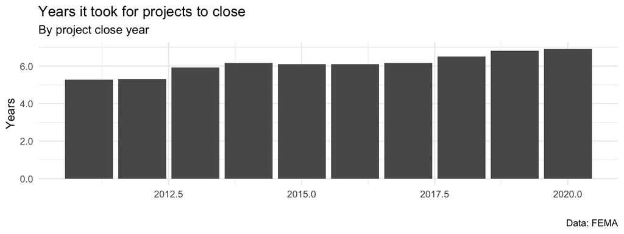

```r
mega_df %>%
  mutate(year_closed=year(dateClosed)) %>%
  mutate(disaster_closed_interval=interval(declarationDate, dateClosed)) %>%
  mutate(months_disaster_closed=disaster_closed_interval %/% months(1)) %>%
  mutate(months_disaster_closed=case_when(
    months_disaster_closed < 0 ~ 0,
    TRUE ~ months_disaster_closed
  )) %>%
  filter(year_closed>2010 & year_closed < 2021) %>%
  group_by(year_closed) %>%
  #filter(initially_approved_year>2010) %>%
  summarize(total=n(),
            months_disaster_closed=round(mean(months_disaster_closed, na.rm=T),1)) %>%
  mutate(years=months_disaster_closed/12) %>%
  filter(year_closed>2010) %>%
  ggplot(aes(x=year_closed, y=years)) +

  geom_bar(position="stack", stat="identity") +
  #facet_wrap(~still_open) +
  scale_y_continuous(labels = scales::comma) +
  labs(title="Years it took for projects to close",
       subtitle="By project close year",
       caption="Data: FEMA",
       y="Years",
       x="") +
  theme_minimal()
```

It takes nearly two years for projects in rural counties to get approved.

```r
# import county census data (poverty, urban, race)
county_data <- read_csv("../../data/clean/county_combined.csv") %>%
  mutate(pov_quantile= ntile(pctpov, 4))  %>%
  mutate(pop_quantile=ntile(poverty_population, 4))

# import county names
county_names <- read_csv("../../data/clean/county_names.csv")

county_data <- county_data %>% left_join(county_names)

mega_df %>%
     mutate(fipsStateCode=case_when(
         nchar(stateNumberCode)==1 ~ paste0("0", stateNumberCode),
         TRUE ~ as.character(stateNumberCode)
     )) %>%
     mutate(fipsCountyCode=case_when(
         nchar(countyCode)==1 ~ paste0("00", countyCode),
         nchar(countyCode)==2 ~ paste0("0", countyCode),
         is.na(countyCode) ~ "000",
         TRUE ~ as.character(countyCode)
     )) %>%
     mutate(GEOID=paste0(fipsStateCode, fipsCountyCode)) %>%
     left_join(county_data, by="GEOID") %>%
     mutate(ur=case_when(
         (urban_rural > 0 & urban_rural <= 2) ~ "1. Urban",
         (urban_rural > 2 & urban_rural <= 4) ~ "2. Suburban",
         (urban_rural > 4 & urban_rural <= 6) ~ "3. Rural",
         TRUE ~ "4. Unclassified"
     )) %>%
     mutate(initially_approved_year=year(approval_date)) %>%
     mutate(initially_declared_approved_interval=interval(declarationDate, approval_date)) %>%
     mutate(months_declared_approved=initially_declared_approved_interval %/% months(1)) %>%
     filter(initially_approved_year>2010) %>%
     group_by(ur) %>%
     summarize(total=n(),
               costs=sum(projectAmount, na.rm=T),
               months_declared_approved=round(mean(months_declared_approved, na.rm=T),1)) %>%
  filter(ur=="3. Rural") %>%
  kable()
```

| ur | total | costs | months_declared_approved |
| --- | --- | --- | --- |
| 3. Rural | 3766 | 2116359580 | 22.4 |

How long it takes counties to close out projects by poverty percentile.

```r
# poor communities
mega_df %>%
     mutate(fipsStateCode=case_when(
         nchar(stateNumberCode)==1 ~ paste0("0", stateNumberCode),
         TRUE ~ as.character(stateNumberCode)
     )) %>%
     mutate(fipsCountyCode=case_when(
         nchar(countyCode)==1 ~ paste0("00", countyCode),
         nchar(countyCode)==2 ~ paste0("0", countyCode),
         is.na(countyCode) ~ "000",
         TRUE ~ as.character(countyCode)
     )) %>%
     mutate(GEOID=paste0(fipsStateCode, fipsCountyCode)) %>%
    mutate(year_closed=year(dateClosed)) %>%
    #mutate(disaster_closed_interval=interval(declarationDate, approval_date)) %>%
    mutate(disaster_closed_interval=interval(declarationDate, dateClosed)) %>%
    mutate(months_disaster_closed=disaster_closed_interval %/% months(1)) %>%
    left_join(county_data, by="GEOID") %>%
    #filter(year(approval_date)>2010) %>%
    filter(year_closed>2010) %>%
     group_by(pov_quantile) %>%
     summarize(total=n(),
               costs=sum(projectAmount, na.rm=T),
               months_declared_closed=round(mean(months_disaster_closed, na.rm=T),1))  %>%
  filter(!is.na(pov_quantile)) %>%
  kable()
```

| pov_quantile | total | costs | months_declared_closed |
| --- | --- | --- | --- |
| 1 | 2294 | 1200396874 | 65.2 |
| 2 | 1999 | 1354363394 | 70.9 |
| 3 | 2476 | 1953018115 | 79.5 |
| 4 | 1715 | 737964092 | 73.0 |

How long it takes to close out projects in counties where majority of the population is either white or non-white.

```r
# white or non-white
mega_df %>%
     mutate(fipsStateCode=case_when(
         nchar(stateNumberCode)==1 ~ paste0("0", stateNumberCode),
         TRUE ~ as.character(stateNumberCode)
     )) %>%
     mutate(fipsCountyCode=case_when(
         nchar(countyCode)==1 ~ paste0("00", countyCode),
         nchar(countyCode)==2 ~ paste0("0", countyCode),
         is.na(countyCode) ~ "000",
         TRUE ~ as.character(countyCode)
     )) %>%
    mutate(GEOID=paste0(fipsStateCode, fipsCountyCode)) %>%
    mutate(year_closed=year(dateClosed)) %>%
    mutate(disaster_closed_interval=interval(declarationDate, approval_date)) %>%
    #mutate(disaster_closed_interval=interval(declarationDate, dateClosed)) %>%
    mutate(months_disaster_closed=disaster_closed_interval %/% months(1)) %>%
    select(-majority) %>%
    left_join(county_data, by="GEOID") %>%
    filter(year(approval_date)>2010) %>%
#    filter(year_closed>2010) %>%
    group_by(majority) %>%
    summarize(total=n(),
               costs=sum(projectAmount, na.rm=T),
               months_declared_closed=round(mean(months_disaster_closed, na.rm=T),1)) %>%
  filter(!is.na(majority)) %>%
  kable()
```

| majority | total | costs | months_declared_closed |
| --- | --- | --- | --- |
| Non-White | 1580 | 4504105055 | 27.5 |
| White | 7835 | 6834382034 | 24.2 |

Counties with at least one project that took longer than 10 years to close out where majority of the population is either white or non-white.

```r
tenplus <- mega_df %>%
     mutate(fipsStateCode=case_when(
         nchar(stateNumberCode)==1 ~ paste0("0", stateNumberCode),
         TRUE ~ as.character(stateNumberCode)
     )) %>%
     mutate(fipsCountyCode=case_when(
         nchar(countyCode)==1 ~ paste0("00", countyCode),
         nchar(countyCode)==2 ~ paste0("0", countyCode),
         is.na(countyCode) ~ "000",
         TRUE ~ as.character(countyCode)
     )) %>%
    mutate(GEOID=paste0(fipsStateCode, fipsCountyCode)) %>%
    mutate(year_closed=year(dateClosed)) %>%
    #mutate(disaster_closed_interval=interval(declarationDate, dateClosed)) %>%
    mutate(disaster_closed_interval=interval(declarationDate, approval_date)) %>%
    mutate(months_disaster_closed=disaster_closed_interval %/% months(1)) %>%
    select(-majority) %>%
    left_join(county_data, by="GEOID") %>%
    filter(months_disaster_closed>120) %>%
  mutate(year_approved=year(approval_date)) %>%
  filter(year_approved>2010)
  #filter(year_closed>2010)

# Counties with at least one project that took longer than 10 years to close out
tenplus %>%
    count(GEOID) %>%
    mutate(project=1) %>%
    right_join(county_data, by="GEOID") %>%
    group_by(majority) %>%
    summarize(total=n(),
              counties=sum(project, na.rm=T)) %>%
  ungroup() %>%
  mutate(percent_of_counties=round(counties/total*100,1)) %>%
  kable()
```

| majority | total | counties | percent_of_counties |
| --- | --- | --- | --- |
| Non-White | 462 | 5 | 1.1 |
| White | 2758 | 11 | 0.4 |

Counties with projects that took longer than 10 years to close out in counties by poverty quantiles.

```r
tenplus <- mega_df %>%
     mutate(fipsStateCode=case_when(
         nchar(stateNumberCode)==1 ~ paste0("0", stateNumberCode),
         TRUE ~ as.character(stateNumberCode)
     )) %>%
     mutate(fipsCountyCode=case_when(
         nchar(countyCode)==1 ~ paste0("00", countyCode),
         nchar(countyCode)==2 ~ paste0("0", countyCode),
         is.na(countyCode) ~ "000",
         TRUE ~ as.character(countyCode)
     )) %>%
    mutate(GEOID=paste0(fipsStateCode, fipsCountyCode)) %>%
    mutate(year_closed=year(dateClosed)) %>%
    mutate(disaster_closed_interval=interval(declarationDate, dateClosed)) %>%
    mutate(months_disaster_closed=disaster_closed_interval %/% months(1)) %>%
    select(-majority) %>%
    left_join(county_data, by="GEOID") %>%
    filter(months_disaster_closed>120) %>%
    filter(year_closed>2010)

tenplus %>%
    mutate(project=1) %>%
    group_by(GEOID) %>%
    summarize(projects=sum(project, na.rm=T)) %>%
    right_join(county_data, by="GEOID") %>%
    group_by(pov_quantile) %>%
    summarize(total=n(),
              counties=sum(projects, na.rm=T)) %>%
  filter(!is.na(pov_quantile)) %>%
  kable()
```

| pov_quantile | total | counties |
| --- | --- | --- |
| 1 | 805 | 73 |
| 2 | 805 | 136 |
| 3 | 805 | 349 |
| 4 | 805 | 158 |

Average number of disasters affecting counties while waiting for relevant hazard mitigation projects.

```r
project_types <- read_csv("../../data/raw/project_types.csv")

mega_df <- mega_df %>%
  left_join(project_types)

mega_df <- mega_df %>%
  mutate(incident_count=str_count(disaster_wide_type, incidentType))

mega_df %>%
  filter(subappType!="Management Costs") %>%
  filter(subappType!="Planning") %>%
  filter(programFy>2010) %>%
  group_by(incidentType) %>%
  summarize(average_disaster_count=round(mean(incident_count, na.rm=T),1)) %>%
  arrange(-average_disaster_count) %>%
  head(3) %>%
  kable()
```

| incidentType | average_disaster_count |
| --- | --- |
| Typhoon | 3.2 |
| Fire | 2.9 |
| Hurricane | 2.2 |

```r
#Hurricane
hurricanes <-
     mega_df %>%
     filter(subappType!="Management Costs") %>%
     filter(subappType!="Planning") %>%
     filter(programFy>2010) %>% filter(incidentType=="Hurricane")

stc <- mega_df %>%
  filter(year(approval_date)>2010) %>%
  filter(county=="St. Charles")
#Fire

#Severe Ice Storm
ice <-
     mega_df %>%
     filter(subappType!="Management Costs") %>%
     filter(subappType!="Planning") %>%
     filter(programFy>2010) %>% filter(incidentType=="Severe Ice Storm")
# too many are still open

#Flood
Flood <-
     mega_df %>%
     filter(subappType!="Management Costs") %>%
     filter(subappType!="Planning") %>%
     filter(programFy>2010) %>% filter(incidentType=="Flood")


#Tornado
tornados <-
     mega_df %>%
     filter(subappType!="Management Costs") %>%
     filter(subappType!="Planning") %>%
     filter(programFy>2010) %>% filter(incidentType=="Tornado")

typh<-
     mega_df %>%
     filter(subappType!="Management Costs") %>%
     filter(subappType!="Planning") %>%
     filter(programFy>2010) %>% filter(incidentType=="Typhoon")
```

Disasters compared to projects by county type.

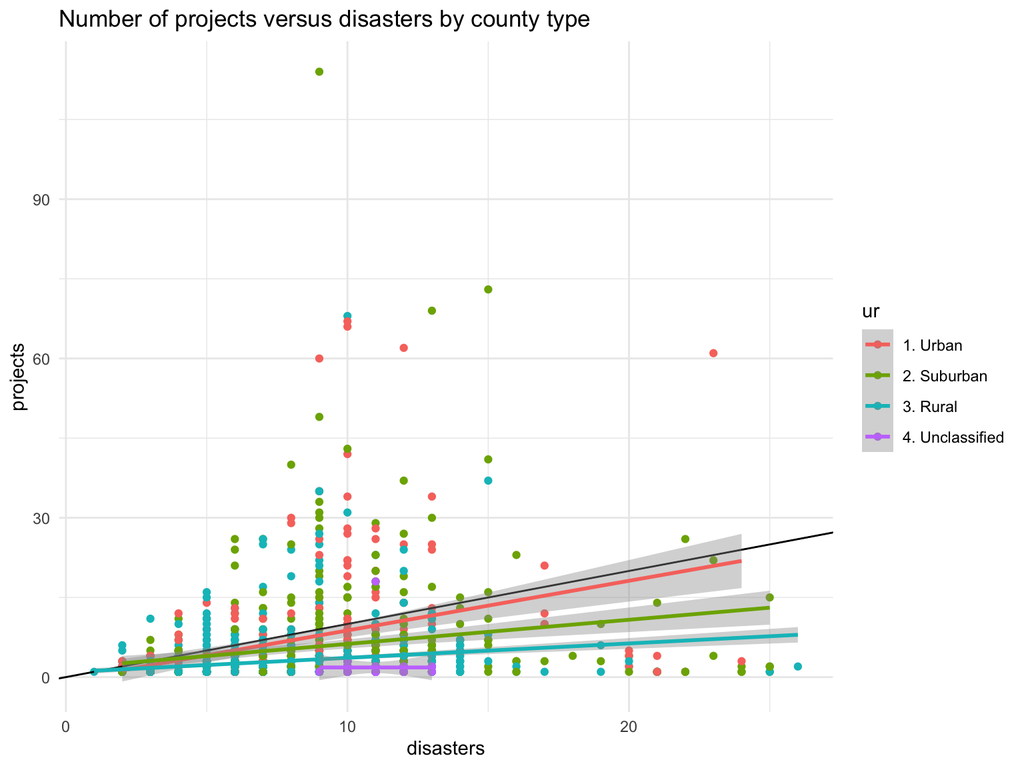

```r
disasters <- read_csv("../../data/raw/DisasterDeclarationsSummaries090321.csv") %>%
  mutate(GEOID=paste0(fipsStateCode, fipsCountyCode))

# import county census data (poverty, urban, race)
county_data <- read_csv("../../data/clean/county_combined.csv") %>%
  mutate(pov_quantile= ntile(pctpov, 4))  %>%
  mutate(pop_quantile= ntile(poverty_population,4))
# import county names (whoops)
county_names <- read_csv("../../data/clean/county_names.csv")

county_data <- county_data %>% left_join(county_names)


county_disaster_list <- disasters %>%
  ungroup() %>%
  select(-placeCode, -designatedArea, -hash, -id) %>%
  unique() %>%
  mutate(declaration_year=year(declarationDate)) %>%
  filter(declaration_year>2010)

write_csv(county_disaster_list, "../../data/clean/county_disaster_list_dupe.csv", na="")

county_disaster_list <- read_csv("../../data/clean/county_disaster_list_dupe.csv") %>%
  unique()

county_disaster_count <- county_disaster_list %>%
  count(GEOID, name="disasters") %>%
  full_join(county_data) %>%
  mutate(ur=case_when(
    (urban_rural > 0 & urban_rural <= 2) ~ "1. Urban",
    (urban_rural > 2 & urban_rural <= 4) ~ "2. Suburban",
    (urban_rural > 4 & urban_rural <= 6) ~ "3. Rural",
    TRUE ~ "4. Unclassified"
  )) %>%
  filter(!is.na(NAME))

county_projects_count <- mega_df %>%
  filter(programArea=="HMGP") %>%
  filter(year(declarationDate)>2010) %>%
#  filter(is.na(dateClosed) | year(dateClosed)>2010) %>%
  mutate(fipsStateCode=case_when(
    nchar(stateNumberCode)==1 ~ paste0("0", stateNumberCode),
    TRUE ~ as.character(stateNumberCode)
  )) %>%
  mutate(fipsCountyCode=case_when(
    nchar(countyCode)==1 ~ paste0("00", countyCode),
    nchar(countyCode)==2 ~ paste0("0", countyCode),
    is.na(countyCode) ~ "000",
    TRUE ~ as.character(countyCode)
  )) %>%
  mutate(GEOID=paste0(fipsStateCode, fipsCountyCode)) %>%
  count(GEOID, name="projects")

county_projects_disasters <- full_join(county_disaster_count, county_projects_count) %>%
  filter(!is.na(NAME))

ggplot(county_projects_disasters, aes(x=disasters, y=projects, color=ur)) +
  geom_point()+
  #geom_smooth(method='lm', formula= y~x, se=FALSE) +
  geom_abline(intercept=0, slope=1) +
  geom_smooth(method=lm) +
  labs(title="Number of projects versus disasters by county type") +
  theme_minimal()
```

Urban counties are twice as likely on average to receive funding after a disaster than rural areas.

```r
county_projects_disasters %>%
  mutate(projects2=case_when(
    is.na(projects) ~ 0,
    TRUE ~ as.numeric(projects)
  ),
  disasters2=case_when(
    is.na(disasters) ~ 0,
    TRUE ~ as.numeric(disasters)
  )) %>%
  mutate(ratio=projects2/disasters2) %>%
  group_by(ur) %>%
  summarize(average_ratio = mean(ratio, na.rm=T)) %>%
  kable()
```

| ur | average_ratio |
| --- | --- |
| 1. Urban | 0.5252977 |
| 2. Suburban | 0.4593427 |
| 3. Rural | 0.2310508 |
| 4. Unclassified | 0.0703265 |

Half of all rural counties in the U.S. experienced a disaster over the past 10 years, yet didn’t have a single mitigation project.

```r
disasters_counties <- read_csv("../../data/raw/DisasterDeclarationsSummaries090321.csv") %>%
  mutate(GEOID=paste0(fipsStateCode, fipsCountyCode)) %>%
  filter(incidentType=="Biological") %>%
  filter(year(declarationDate)>2010) %>%
  select(GEOID) %>%
  unique()


counties_only <- mega_df %>%
  filter(year(declarationDate)>2010) %>%
  select(GEOID) %>%
  unique() %>%
  left_join(county_data, by="GEOID") %>%
  mutate(ur=case_when(
      (urban_rural > 0 & urban_rural <= 2) ~ "1. Urban",
      (urban_rural > 2 & urban_rural <= 4) ~ "2. Suburban",
      (urban_rural > 4 & urban_rural <= 6) ~ "3. Rural",
      TRUE ~ "4. Unclassified"
    )) %>%
    count(ur, name="counties_with_projects")

no_mitigation <- readRDS("../../data/clean/no_mitigation.RDS")
county_data_none <- county_data %>%
  mutate(pov_quantile= ntile(pctpov, 4)) %>%
  filter(GEOID %in% no_mitigation)

total_ur <- county_data %>%
  count(urban_rural, name="total_counties")
#
# county_data_none %>%
#   count(urban_rural) %>%
#   left_join(total_ur) %>%
#   mutate(percent=round(n/total_counties*100,1)) %>%
#   rename(counties_with_no_projects=n,
#          counties=total_counties) %>%
#   filter(!is.na(urban_rural)) %>%
#   kable()

county_data_none <- county_data %>%
  mutate(pov_quantile= ntile(pctpov, 4)) %>%
  filter(GEOID %in% no_mitigation)

total_ur <- county_data %>%
  count(urban_rural, name="total_counties")

county_data_none %>%
  count(urban_rural) %>%
  left_join(total_ur) %>%
mutate(ur=case_when(
    (urban_rural > 0 & urban_rural <= 2) ~ "1. Urban",
    (urban_rural > 2 & urban_rural <= 4) ~ "2. Suburban",
    (urban_rural > 4 & urban_rural <= 6) ~ "3. Rural",
    TRUE ~ "4. Unclassified"
  )) %>%
  group_by(ur) %>%
  summarize(total_counties=sum(total_counties),
            n=sum(n)) %>%
  left_join(counties_only) %>%
  filter(ur!="4. Unclassified") %>%
  mutate(percent=round(n/total_counties*100,1)) %>%
  rename(type=ur,
         `total counties`=total_counties,
         `qualified counties with no projects`=n,
         `counties with projects`=counties_with_projects,
         `percent counties with no projects`=percent) %>%
  kable()
```

| type | total counties | qualified counties with no projects | counties with projects | percent counties with no projects |
| --- | --- | --- | --- | --- |
| 1. Urban | 436 | 155 | 281 | 35.6 |
| 2. Suburban | 730 | 228 | 502 | 31.2 |
| 3. Rural | 1976 | 908 | 1067 | 46.0 |

Southern states wait longer.

```r
states <- read_csv("../../data/raw/states.csv")

mega_df %>%
  mutate(fipsStateCode=case_when(
    nchar(stateNumberCode)==1 ~ paste0("0", stateNumberCode),
    TRUE ~ as.character(stateNumberCode)
  )) %>%
  mutate(fipsCountyCode=case_when(
    nchar(countyCode)==1 ~ paste0("00", countyCode),
    nchar(countyCode)==2 ~ paste0("0", countyCode),
    is.na(countyCode) ~ "000",
    TRUE ~ as.character(countyCode)
  )) %>%
  mutate(GEOID=paste0(fipsStateCode, fipsCountyCode)) %>%
  mutate(year_closed=year(dateClosed)) %>%
  mutate(disaster_closed_interval=interval(declarationDate, dateClosed)) %>%
  mutate(months_disaster_closed=disaster_closed_interval %/% months(1)) %>%
  filter(year(dateClosed)>2010) %>%
  left_join(states, by=c("fipsStateCode"="st_fips")) %>%
  group_by(region.y) %>%
  summarize(total=n(),
            costs=sum(projectAmount, na.rm=T),
            months_declared_closed=round(mean(months_disaster_closed, na.rm=T),1)) %>%
  arrange(-months_declared_closed) %>%
  filter(!is.na(region.y)) %>%
  kable()
```

| region.y | total | costs | months_declared_closed |
| --- | --- | --- | --- |
| South | 4529 | 2986186893 | 80.9 |
| Northeast | 1431 | 902396328 | 74.4 |
| West | 888 | 520122488 | 73.3 |
| Midwest | 2415 | 1438674982 | 58.1 |

Specifically West South Central, which consists of Arkansas, Louisiana, Oklahoma, and Texas.

```r
mega_df %>%
  mutate(fipsStateCode=case_when(
    nchar(stateNumberCode)==1 ~ paste0("0", stateNumberCode),
    TRUE ~ as.character(stateNumberCode)
  )) %>%
  mutate(fipsCountyCode=case_when(
    nchar(countyCode)==1 ~ paste0("00", countyCode),
    nchar(countyCode)==2 ~ paste0("0", countyCode),
    is.na(countyCode) ~ "000",
    TRUE ~ as.character(countyCode)
  )) %>%
  mutate(GEOID=paste0(fipsStateCode, fipsCountyCode)) %>%
  mutate(year_closed=year(dateClosed)) %>%
  mutate(disaster_closed_interval=interval(declarationDate, dateClosed)) %>%
  mutate(months_disaster_closed=disaster_closed_interval %/% months(1)) %>%
  filter(year(dateClosed)>2010) %>%
  left_join(states, by=c("fipsStateCode"="st_fips")) %>%
  group_by(division) %>%
  summarize(total=n(),
            costs=sum(projectAmount, na.rm=T),
            months_declared_closed=round(mean(months_disaster_closed, na.rm=T),1)) %>%
  arrange(-months_declared_closed) %>%
  filter(!is.na(division)) %>%
  kable()
```

| division | total | costs | months_declared_closed |
| --- | --- | --- | --- |
| West South Central | 1643 | 1370051448 | 97.8 |
| Middle Atlantic | 865 | 783599758 | 77.6 |
| Pacific | 546 | 375097146 | 76.0 |
| East North Central | 470 | 249205028 | 75.8 |
| East South Central | 1506 | 629269697 | 74.4 |
| New England | 566 | 118796570 | 69.6 |
| Mountain | 342 | 145025342 | 69.1 |
| South Atlantic | 1380 | 986865747 | 68.0 |
| West North Central | 1945 | 1189469954 | 53.8 |